# HW03

## Problem 2

#### (a)

$$E[\hat f_b(x)]=E[\frac{1}{100}\sum_{i=1}^{100}K_b(x-x_i)]=E[\int_{-\infty}^\infty K_b(x-x_i)f(x_i)\mathrm d x_i]$$

Based on our setting of $K_b$ and $f(x)$
$$E[\hat f_b(x)]=\frac{1}{w}\int_{x-w/2}^{x+w/2}f(x_i)\mathrm dx_i=\frac{1}{w}(F_{ged,1.5}(x+w/2)-F_{ged,1.5}(x-w/2))$$

#### (b)

The bias should be $E[\hat f_b(x)]-f(x)=\frac{1}{w}[F_{ged,1.5}(x+w/2)-F_{ged,1.5}(x-w/2)]-f_{ged,1.5}(x)$

```r
library(fGarch)
```

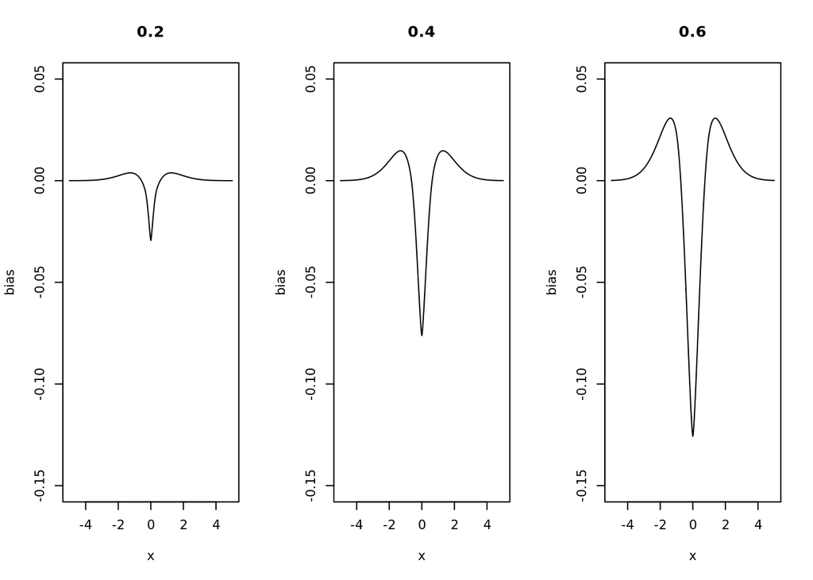

```r
par(mfrow=c(1,3))
x = seq(-5, 5, 0.01)
for(b in c(0.2, 0.4, 0.6))
{
    w = b * 3.464
    bias = (pged(x+w/2, 0, 1, 1.5) - pged(x-w/2, 0, 1, 1.5)) / w - dged(x, 0, 1, 1.5)
    plot(x, bias, type="l", ylim=c(-0.15, 0.05), sub=title(b))
}
```

#### (c)

$$Var[\hat f_b(x)]=\frac{1}{100}Var[K_b(x-x_i)]=\frac{1}{100}[E[(K_b(x-x_i))^2]-(E[K_b(x-x_i)])^2]$$

For $E[K_b(x-x_i)]^2$, from (a) we have $\frac{1}{w^2}[F_{ged,1.5}(x+w/2)-F_{ged,1.5}(x-w/2)]^2$

For $E[(K_b(x-x_i))^2]$, we have
$$\int_{-\infty}^\infty [K_b(x-x_i)]^2f(x_i)\mathrm d x_i=\frac{1}{w^2}(F_{ged,1.5}(x+w/2)-F_{ged,1.5}(x-w/2))$$
Then for the standard deviation, we have
$$\sigma=\frac{1}{10w}\sqrt{[F_{ged,1.5}(x+w/2)-F_{ged,1.5}(x-w/2)]-[F_{ged,1.5}(x+w/2)-F_{ged,1.5}(x-w/2)]^2}$$

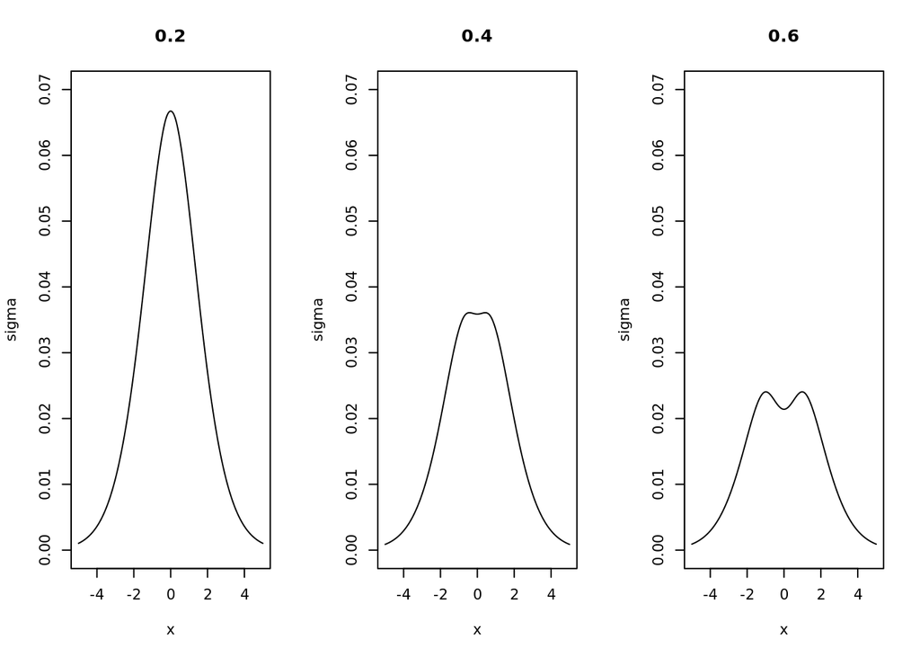

```r
par(mfrow=c(1,3))
x = seq(-5, 5, 0.01)
for(b in c(0.2, 0.4, 0.6))
{
    w = b * 3.464
    lambda = 1
    sigma = (pged(x+w/2, 0, lambda, 1.5) - pged(x-w/2, 0, lambda, 1.5) - (pged(x+w/2, 0, 1, 1.5) - pged(x-w/2, 0, 1, 1.5))^2) ^ 0.5 / (10 * w)
    plot(x, sigma, type="l", ylim=c(0, 0.07), sub=title(b))
}
```

#### (d)

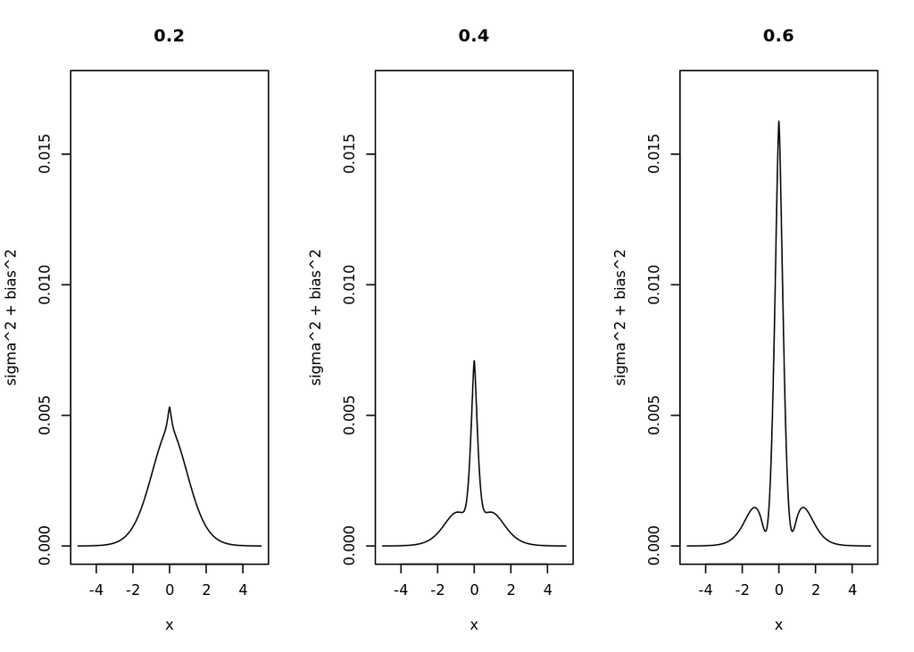

```r
par(mfrow=c(1,3))
x = seq(-5, 5, 0.01)
for(b in c(0.2, 0.4, 0.6))
{
    w = b * 3.464
    lambda = 1
    sigma = (pged(x+w/2, 0, lambda, 1.5) - pged(x-w/2, 0, lambda, 1.5) - (pged(x+w/2, 0, 1, 1.5) - pged(x-w/2, 0, 1, 1.5))^2) ^ 0.5 / (10 * w)
    bias = (pged(x+w/2, 0, 1, 1.5) - pged(x-w/2, 0, 1, 1.5)) / w - dged(x, 0, 1, 1.5)
    plot(x, sigma ^ 2 + bias ^ 2, type="l", ylim=c(0, 0.0175), sub=title(b))
}
```

Based on the plot, I think $b=0.4$, since it gives us a lower maximum MSE than $0.6$ as well as higher kurtosis than $b=0.2$

#### (e)

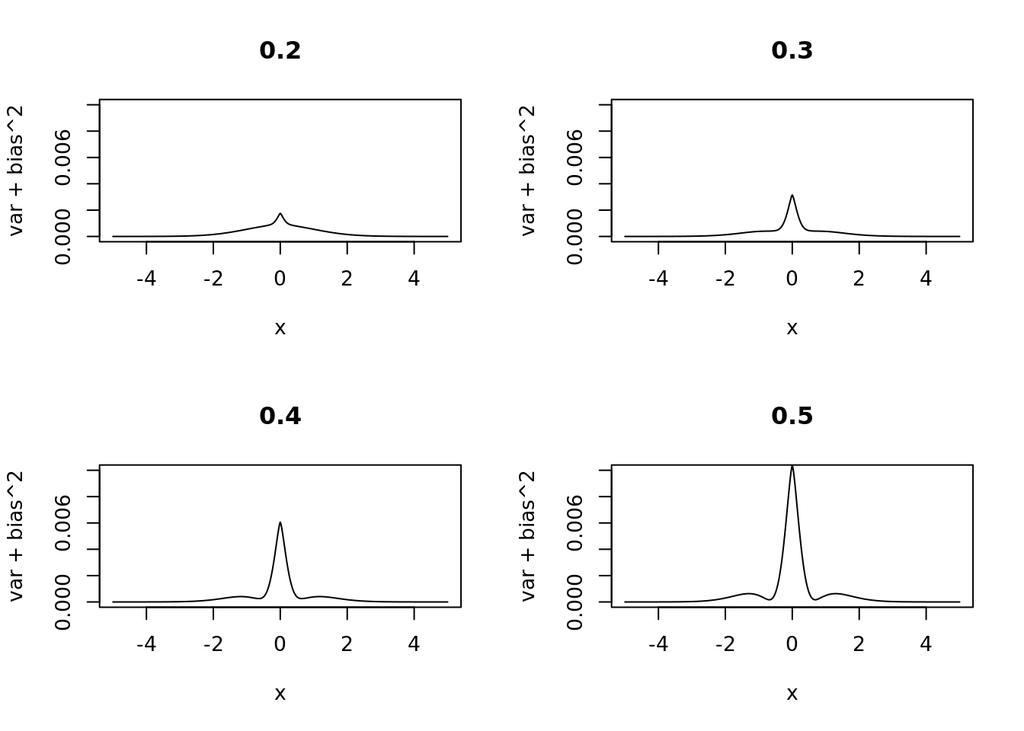

```r
par(mfrow=c(2,2))
x = seq(-5, 5, 0.01)
n = 500
for(b in c(0.2, 0.3, 0.4, 0.5))
{
    w = b * 3.464
    lambda = 1
    var = (pged(x+w/2, 0, lambda, 1.5) - pged(x-w/2, 0, lambda, 1.5) - (pged(x+w/2, 0, 1, 1.5) - pged(x-w/2, 0, 1, 1.5))^2) / (n * w ^ 2)
    bias = (pged(x+w/2, 0, 1, 1.5) - pged(x-w/2, 0, 1, 1.5)) / w - dged(x, 0, 1, 1.5)
    plot(x, var + bias ^ 2, type="l", ylim=c(0, 0.01), sub=title(b))
}
```

Yes, because when the MSE will be much higher if we keep setting $b=4$. Based on the new plots when we have 500 samples, I will decrease the bandwidth to be $0.3$ to have lower MSE as well as kurtosis. Since, we have more samples, there is less probability of overfitting, which means we can use a lower bandwidth.